# rb_views_analysis-Copy1

```python
import pandas as pd
import numpy as np
import json
import swifter
import nltk
import string
import re
import ast
import emoji_data_python
from nltk import word_tokenize
from nltk.corpus import stopwords
from sklearn.model_selection import train_test_split
import codecs
from matplotlib import pyplot as plt
import seaborn as sns
from scipy.spatial import cKDTree as KDTree
from scipy import spatial
from scipy.optimize import linear_sum_assignment
from scipy.spatial.distance import cdist
import warnings
warnings.filterwarnings('ignore')
```

## Generate Test Data

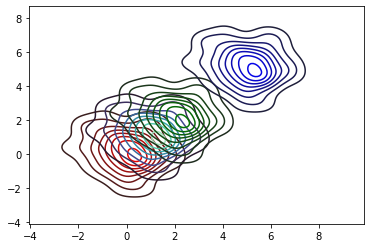

```python
x_a, y_a = np.random.randn(2, 100)
sns.kdeplot(x_a, y_a, color="r")

x_b, y_b = x_a + 1, y_a + 1
sns.kdeplot(x_b, y_b, cmap="mako")

x_c, y_c = x_a + 2, y_a + 2
sns.kdeplot(x_c, y_c, color="g")

x_d, y_d = x_a + 5, y_a + 5
sns.kdeplot(x_d, y_d, color="b")
```

```python
data_a = pd.DataFrame(zip(x_a, y_a))
data_b = pd.DataFrame(zip(x_b, y_b))
data_c = pd.DataFrame(zip(x_c, y_c))
data_d = pd.DataFrame(zip(x_d, y_d))
```

## 2D KL Divergence

The original paper: https://ieeexplore.ieee.org/document/4595271

Equation 14.

Its value always $\geq$ 0

Cons:

1. It's not symmetric
2. It does not satisfy the triangle inequality. D(A||C) - (D(A||B)+ D(B||C)) > 0
3. It's not a distance metric, indicated by 2
4. If two clusters are too far away (no overlap), KL divergence makes no sense

```python
def KLdivergence(x, y):
    """
    x : 2D array (n,d)
    Samples from distribution P, which typically represents the true distribution.
    y : 2D array (m,d)
    Samples from distribution Q, which typically represents the approximate distribution.
    """

    # check the dimensions are consistent
    x = np.atleast_2d(x)
    y = np.atleast_2d(y)

    # num of samples, num of dims
    n, d = x.shape
    m, dy = y.shape

    assert(d == dy)

    # build a KD tree representation of the samples and find the nearest neighbour
    # of each point in x.
    xtree = KDTree(x)
    ytree = KDTree(y)

    # get the first two nearest neighbours for x, since the closest one is the
    # sample itself.
    r = xtree.query(x, k=2, eps=.01, p=2)[0][:,1]
    s = ytree.query(x, k=1, eps=.01, p=2)[0]

    return -np.log(r/s).sum() * d / n + np.log(m / (n - 1.))
```

```python
KLdivergence(data_a, data_b)
```

```
0.9797675778240689
```

```python
KLdivergence(data_a, data_c)
```

```
3.3216739814326766
```

```python
KLdivergence(data_a, data_d)
```

```
7.968259006037792
```

```python
KLdivergence(data_d, data_a)  # not symmetric
```

```
8.804185745925443
```

## 2D JS Divergence

Overcome some of KLD's problems.

Pros: Symmetric

Cons: When two distributions are super far away, JS Divergence is a constant, which is bad for deep learning optimization. (bad loss function)

```python
def JSdivergence(x, y):
    """
    x : 2D array (n,d)
    Samples from distribution P, which typically represents the true distribution.
    y : 2D array (m,d)
    Samples from distribution Q, which typically represents the approximate distribution.
    """

    x_y = (x + y) / 2

    return 0.5 * KLdivergence(x, x_y) + 0.5 * KLdivergence(y, x_y)
```

```python
JSdivergence(data_a, data_b)
```

```
0.2203225924388904
```

```python
JSdivergence(data_a, data_c)
```

```
1.033911317854761
```

```python
JSdivergence(data_a, data_d)
```

```
4.968798165368965
```

```python
JSdivergence(data_d, data_a)  # symmetric!
```

```
4.968798165368965
```

## Earth Mover's Distance (Wasserstein Distance)

EMD calculation can boil down to a linear assignment problem, which is:

$\textrm{dist_EMD} = \min_{\gamma_{i,j} \geq 0} \sum_{i,j} \gamma_{i,j} d_{i,j}\quad \text{s.t.} \quad \sum_j \gamma_{i,j}=p_i,\ \sum_i \gamma_{i,j}=q_j$

```python
def EMD_2D(x, y):
    # check the dimensions are consistent
    x = np.atleast_2d(x)
    y = np.atleast_2d(y)

    # cosine distance as cost
    d = cdist(x, y)

    # linear assignment
    assignment = linear_sum_assignment(d)
    return d[assignment].sum() / n
```

```python
EMD_2D(data_a, data_b)
```

```
1.4142135623730956
```

```python
EMD_2D(data_a, data_c)
```

```
2.828427124746191
```

```python
EMD_2D(data_a, data_d)
```

```
7.071067811865478
```

```python
EMD_2D(data_d, data_a) # symmetric as well
```

```
7.071067811865478
```

### Verification Test

```python
def EMD_1D(x, y):
    # cosine distance as cost
    d =  np.abs(x - y.reshape((n, 1)))

    # linear assignment
    assignment = linear_sum_assignment(d)
    return d[assignment].sum() / n
```

```python
np.random.seed(0)
n = 100

test_data_a = np.random.randn(n)
test_data_b = np.random.randn(n) - 2

# ground truth from scipy
print(wasserstein_distance(test_data_a, test_data_b))

# our 1D version
print(EMD_1D(test_data_a, test_data_b))
```

```
1.977795044786648
1.9777950447866477
```